# Project 4 Act Report - Meng Tan

## Data Set Information

Twitter user **@dog_rates**, also known as **WeRateDogs**, has tweeted thousands of dog pictures and rated them with their specific rating system in Twitter. After gathering these pictures and twitter texts from multiple sources, such as website url, Twitter API, etc. , we have assessed and cleaned the data. In this report, we want to share some information we obtained from the cleaned data.

```python
import matplotlib.pyplot as plt
import matplotlib.image as mpimg

def show_pic(filepath):
    img = mpimg.imread(filepath)
    plt.figure(figsize=(10,8))
    imgplot = plt.imshow(img)
    plt.axis('off')
    plt.show()
```

## Exploratory Data Analysis

In particular, we have found out the answer for:

- Which time period during a day sees a highest number of tweets?
- Which is the favorite source for WeRateDogs?
- Which dog stage gets higher ratings?
- Which breed of dog appears most often?
- Is there any relationship between rating_numerator and favorite_count?

### Which time period during a day sees a highest number of tweets?

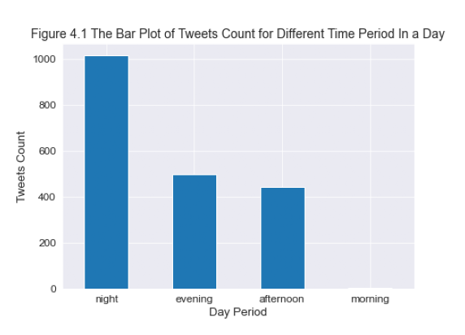

```python
show_pic('1_tweet_time.png')
```

**From above figure, we can conclude that more than half of tweets tweeted during night, specifically from 00:00 to 06:00, and in the morning, there nearly no tweets.**

### Which is the favorite source for WeRateDogs?

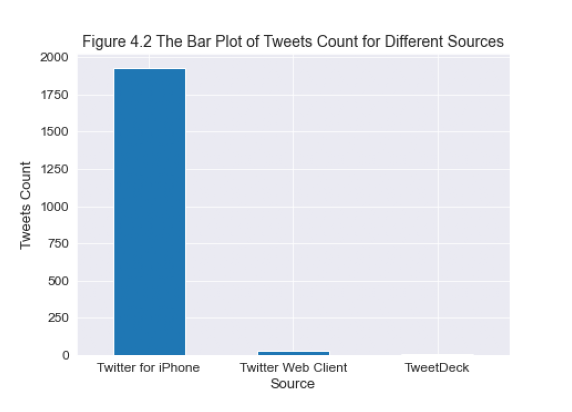

```python
show_pic('2_source_count.png')
```

**From above figure, it is clear that WeRateDogs like tweeting tweeters with Twitter for iPhone.**

### Which dog stage gets higher ratings?

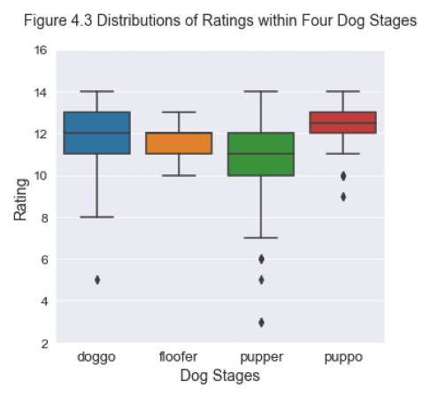

```python
show_pic('3_rating_stage.png')
```

**From the above figure, puppo seems to have higher average ratings than other three stages among all the stage-labeled dogs.**

### Which breed of dog appears most often?

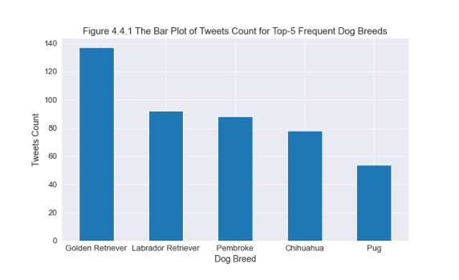

```python
show_pic('4_breed_count.png')
```

**From #1 prediction, Golden Retriever seems to be the dog breed appears most often.**

### Fancier visualisations with wordcloud

**Source of original dog pictures in wordclouds:**

- first wordcloud: https://www.shutterstock.com/search/running+dog+silhouette
- second wordcloud: https://www.bostonmagazine.com/arts-entertainment/2017/04/18/dog-rates-mit/

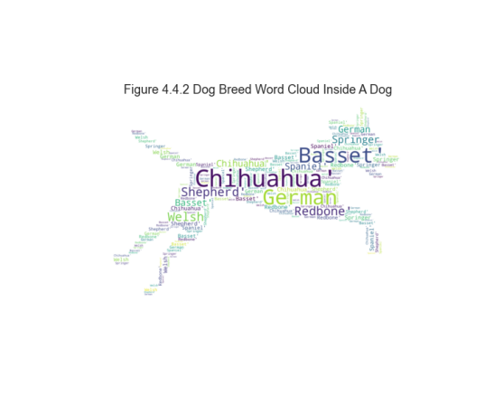

```python
show_pic('dog_wordcloud_white.png')
```

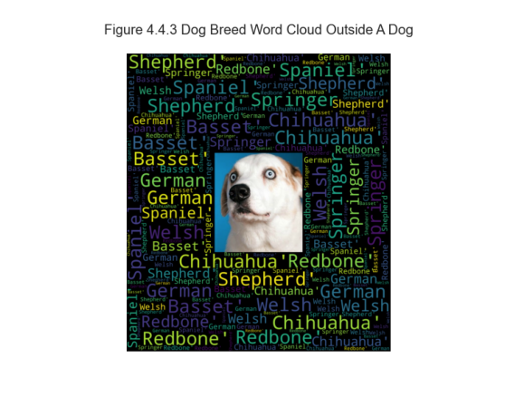

```python
show_pic('dog_wordcloud_black.png')
```

### Is there any relationship between rating_numerator and favorite_count?

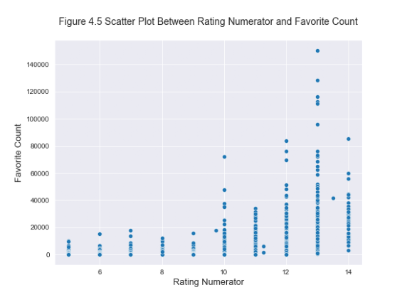

```python
show_pic('5_rating_favorite.png')
```

**From above figure, we can see that rating numerator 13 obtains more higher favorites, lower numerators shows less chance to get more than 20,000 favorites.**

## Conclusion

To summarise, what we can get from this report:

- more than half of tweets tweeted during night, specifically from 00:00 to 06:00, and in the morning, there nearly no tweets
- WeRateDogs like tweeting tweeters with Twitter for iPhone
- puppo seems to have higher average ratings than other three stages among all the stage-labeled dogs
- Golden Retriever seems to be the dog breed appears most often
- rating numerator 13 obtains more higher favorites, lower numerators shows less chance to get more than 20,000 favorites